# EDA and SVM writing

Shun Xie

2023-05-08

```r
library(gridExtra)
library(tidyverse)
library(ggplot2)
library(dplyr)
library(caret)
library(corrplot)
```

# Regression

## EDA

We consider the EDA for the training data, which we will use later on to train our models. Recovery data contains 6 continuous predictors, namely age, height, weight, bmi, Systolic blood pressure (SBP) and LDL cholesterol (LDL), as well as 8 discrete/factor predictors, namely gender, race, smoking, hypertension, diabetes, vaccine status, Severity of COVID-19 infection and study which the data belongs to. The response value is the time for recovery. It is a continuous variable. \

Distribution of data is included in appendix 1. In accordance to distribution of continuous variables, only the recovery time, which is the response, has a right skewed shape. All predictors are normally distributed with symmetric density plot. \

The correlation plot (only considers continuous variable), calculated from Pearson Correlation in appendix 2, gives an insight of linear correlation between continuous predictors and transformed recovery time. It can be seen that bmi and weight have a relatively weak positive relation with log recovery time whereas height may have a weak negative linear correlation with log recovery time. While linear trend may be sufficient in some cases, some data may show a non-linear correlation with log recovery time. As shown in appendix 3, weight and bmi is likely to have a non-linear correlation with the response, suggesting a motivation to consider non-linear method.

## SVM

Support Vector Machine can be utilized in a classification problem. By constructing a boundary, it is able to classify into two categories based on predictors. During the training process, a soft margin SVM minimize $\frac{1}{2}||\beta^2+C\sum^n_{i=1}\xi_i$ where the optimal Cost parameter C can be chosen based on 10-fold CV. If inner product is used in predicting f(x), it is a Support vector classifier or linear SVM. It will become SVM with radial kernel if inner product is replaced by $exp(-\gamma\sum^p_{j=1}(x_{ij}-x_{i’j}^2)$. In this case, optimal pair of cost and $\gamma$ can be obtained by 10-fold CV. Both cases are considered in our study.

# Appendix

## Appendix 1

```
## [1] 3593
```

```
##      age gender race smoking height weight  bmi hypertension diabetes SBP LDL
## 2989  63      1    1       0  174.8   83.6 27.4            1        0 137 108
## 620   60      1    1       0  170.0   80.7 27.9            0        0 128  80
## 9226  64      0    1       0  167.5   89.1 31.7            1        0 137 126
## 4098  69      0    1       2  173.0   72.5 24.2            1        0 135 149
## 8349  62      0    1       0  172.6   82.4 27.7            1        0 138 136
## 184   60      1    1       0  166.5   82.9 29.9            0        0 128 118
##      vaccine severity study recovery_time
## 2989       1        0     B            14
## 620        1        0     A            36
## 9226       0        0     C            50
## 4098       0        0     B            65
## 8349       1        0     C            34
## 184        1        0     A            32
```

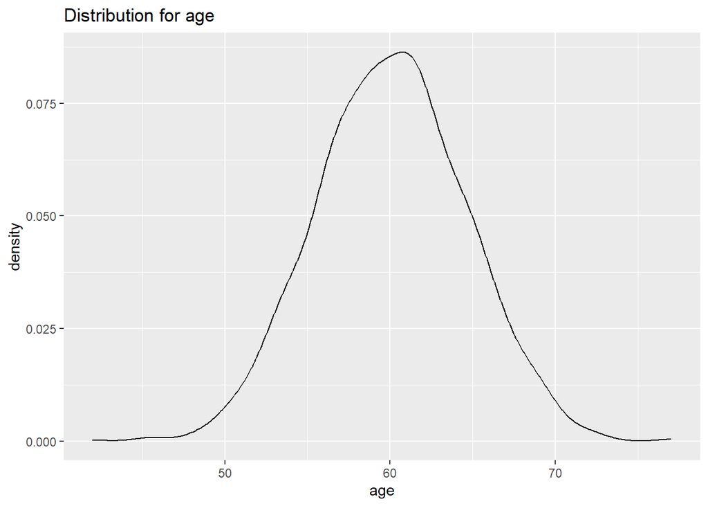

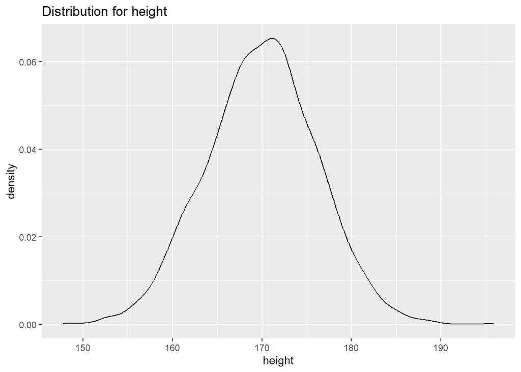

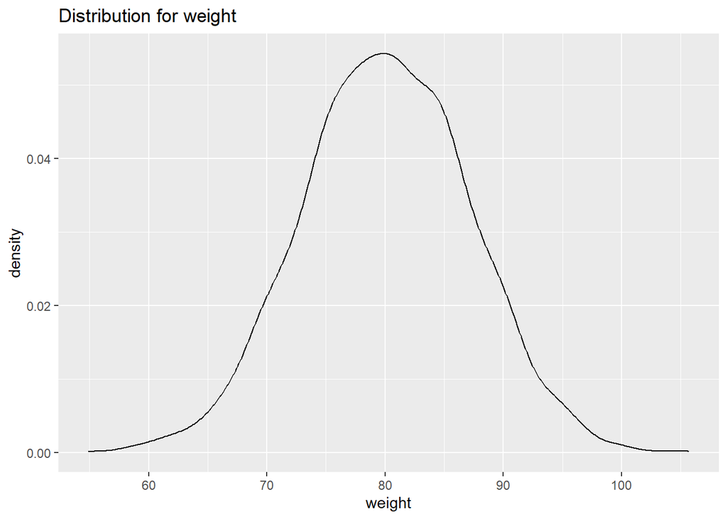

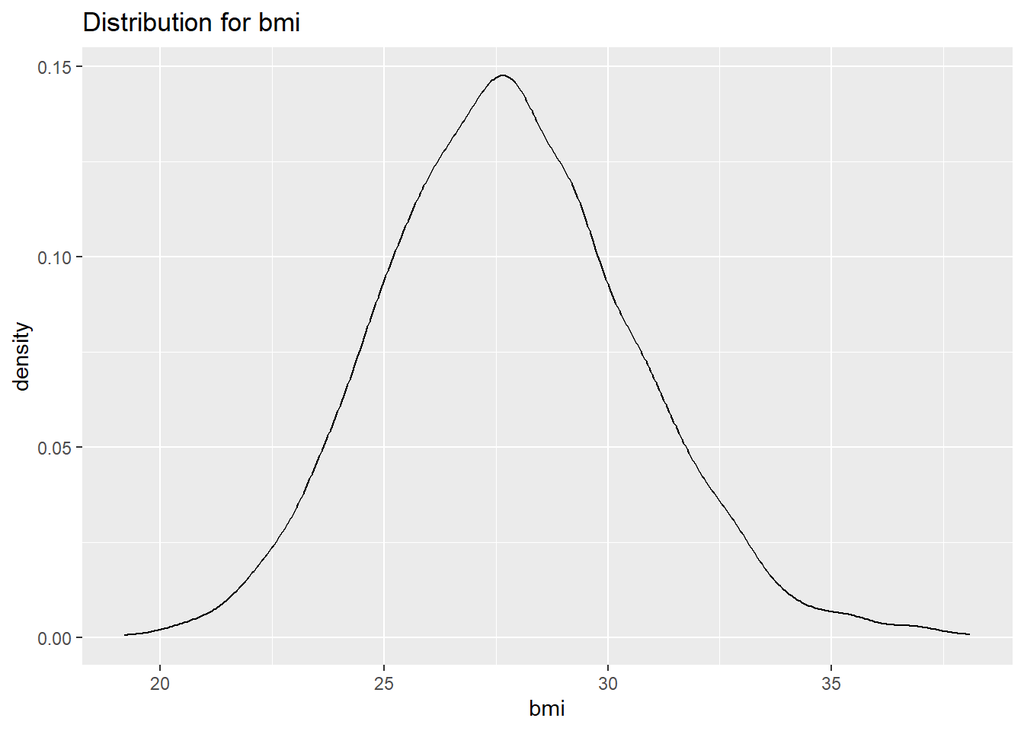

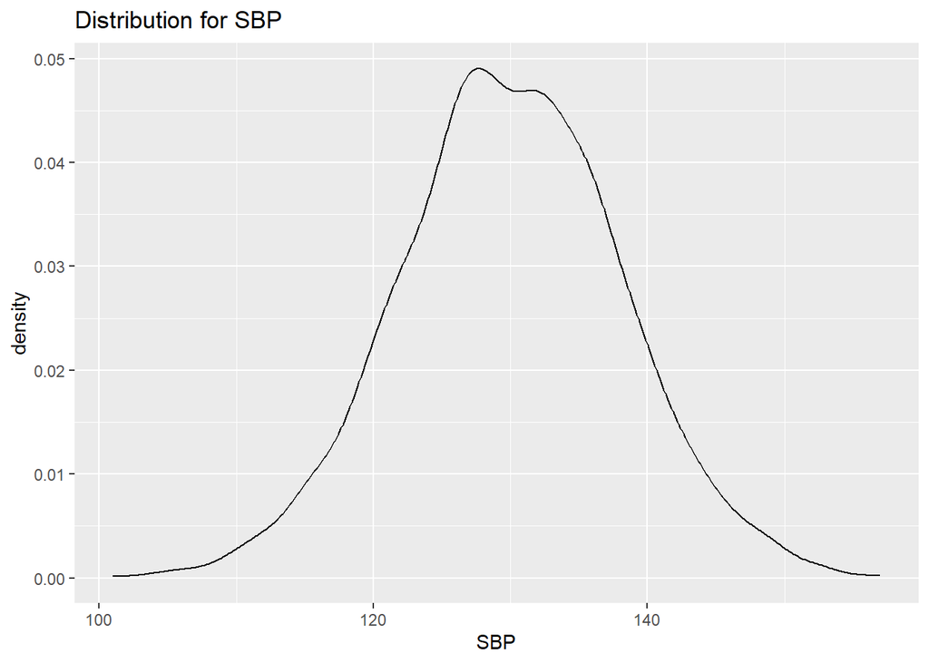

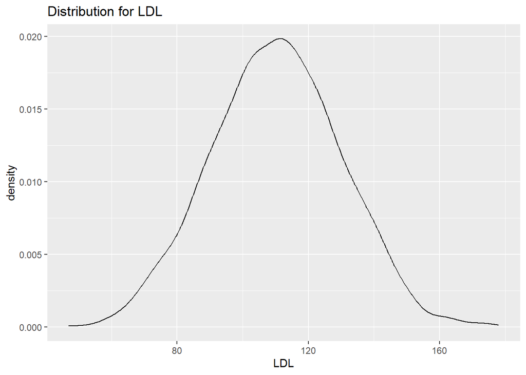

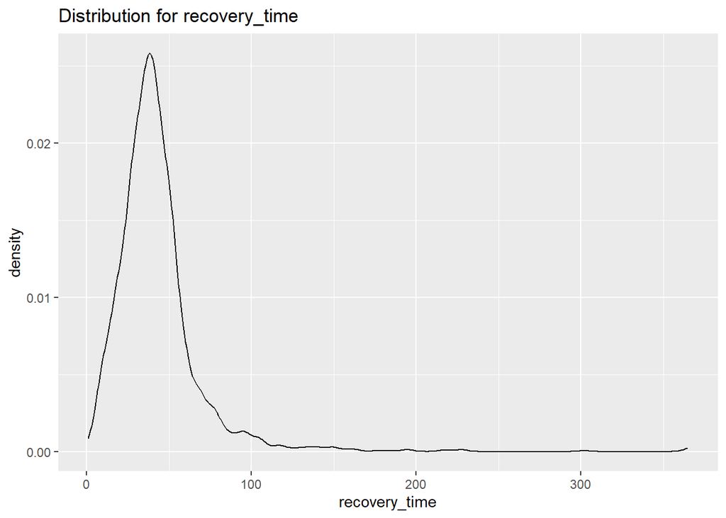

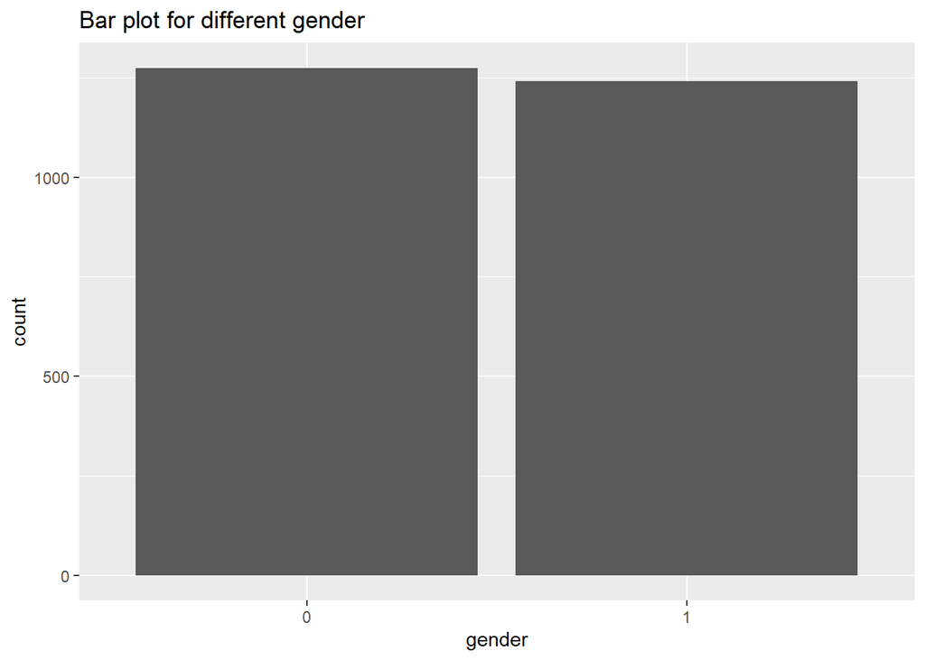

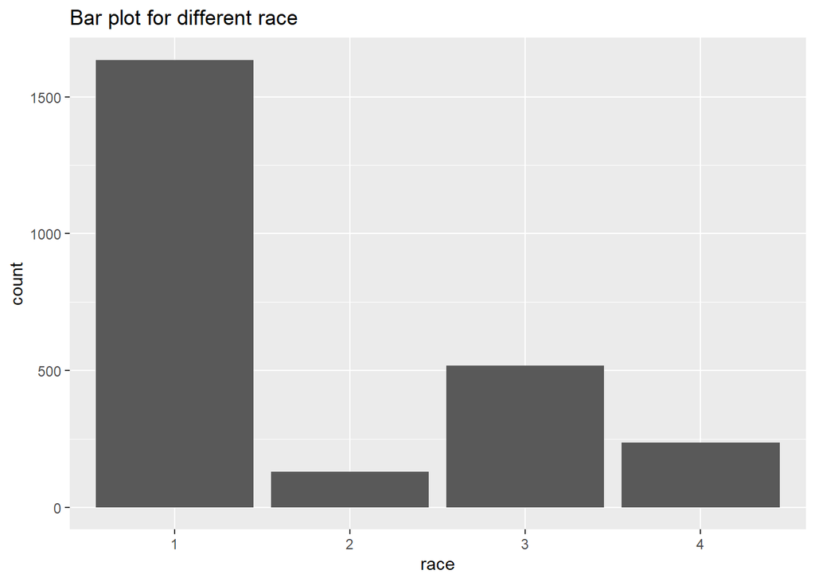

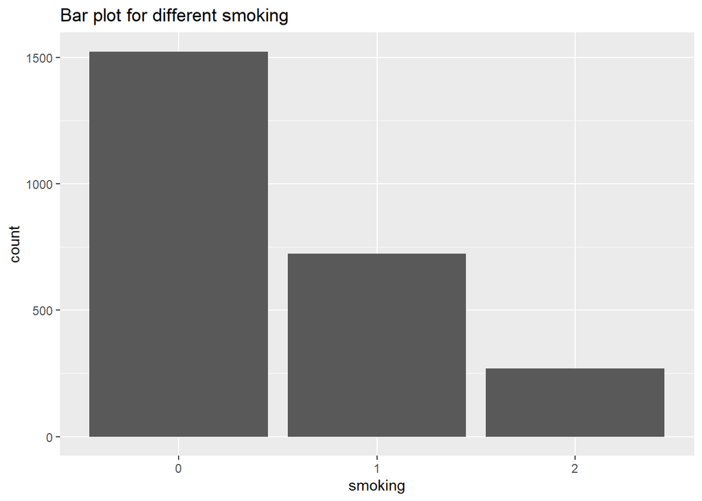

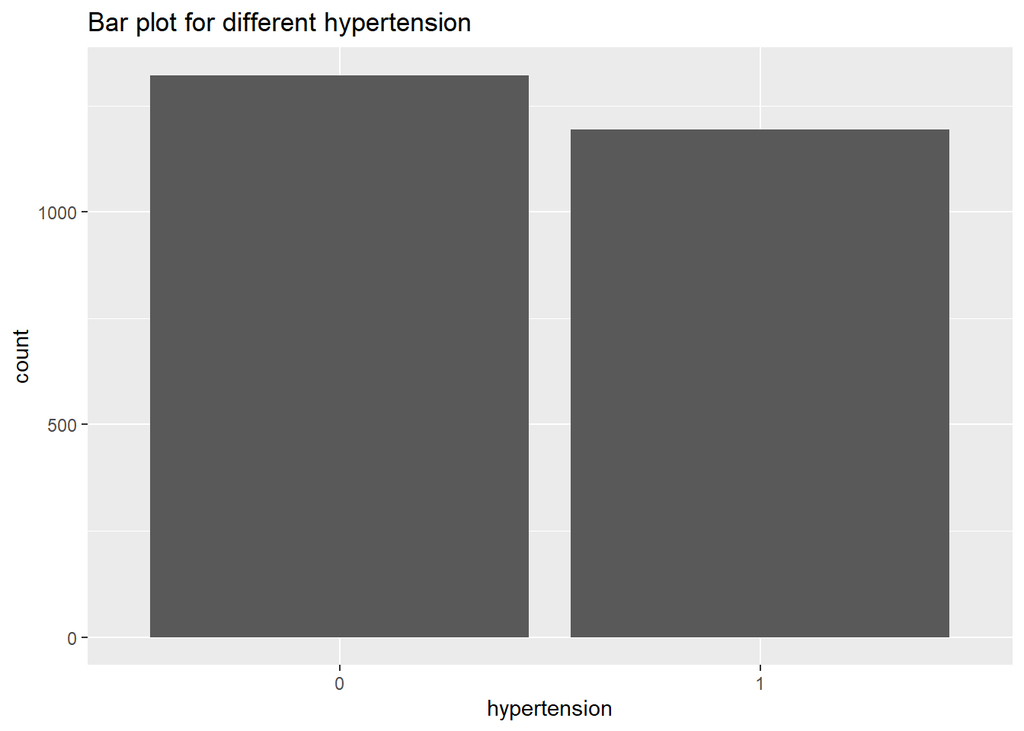

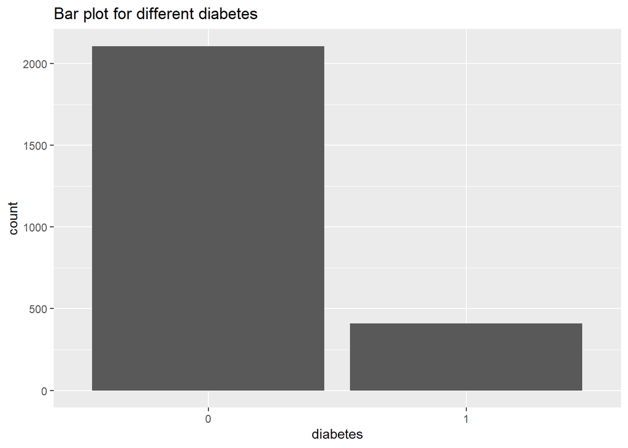

[3 more figures not shown]

## Appendix 2

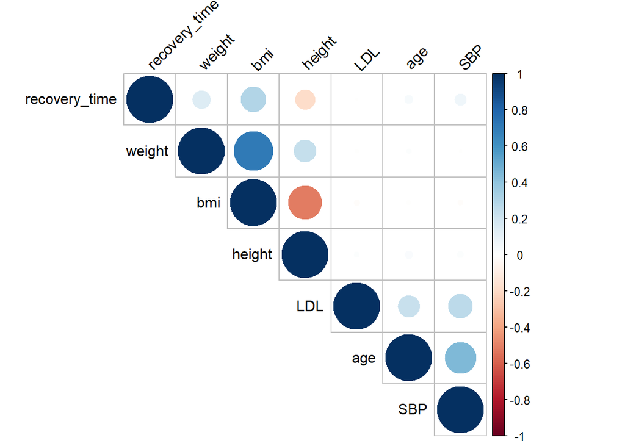

## Appendix 3

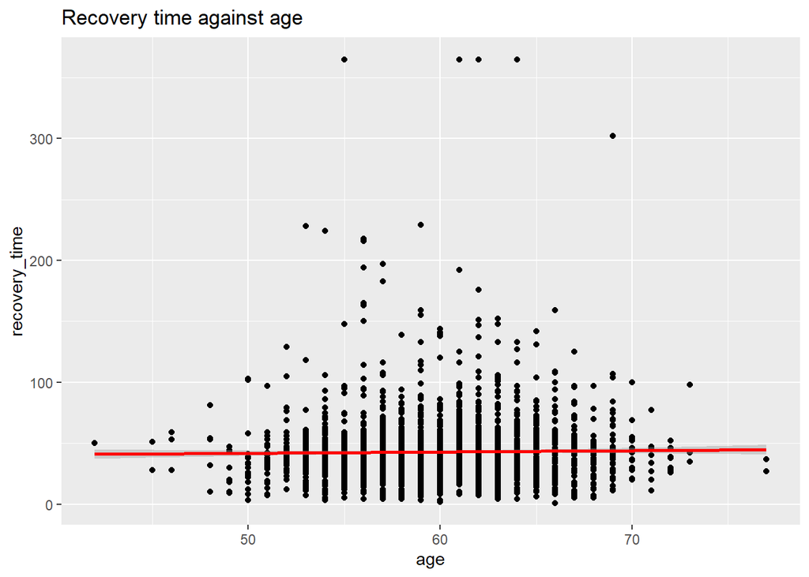

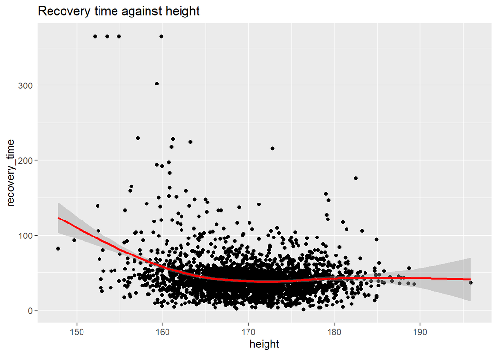

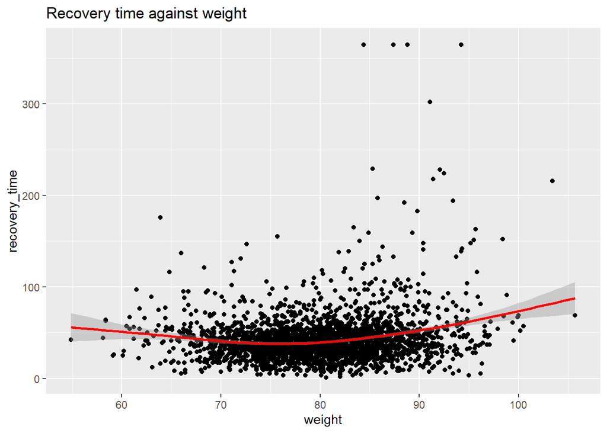

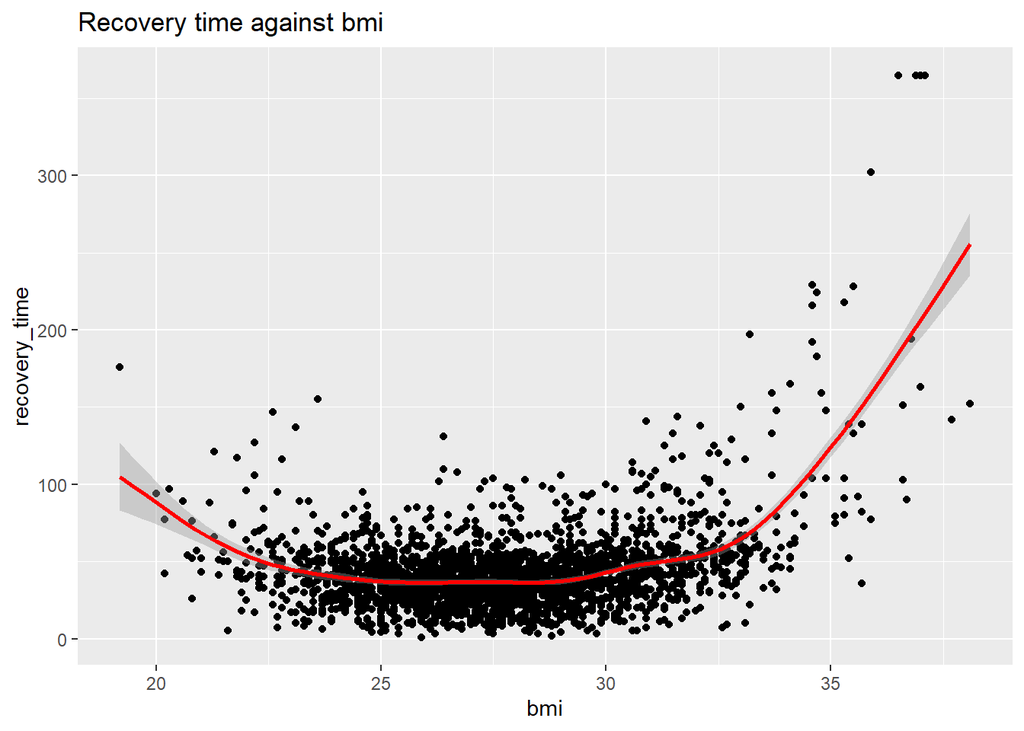

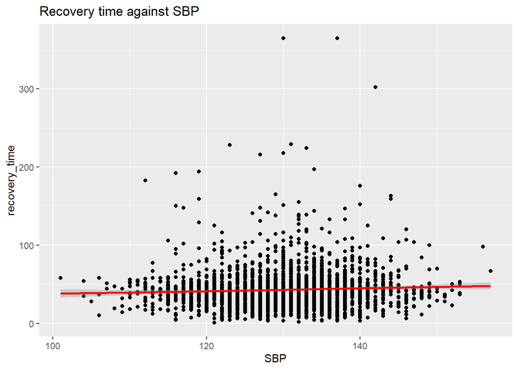

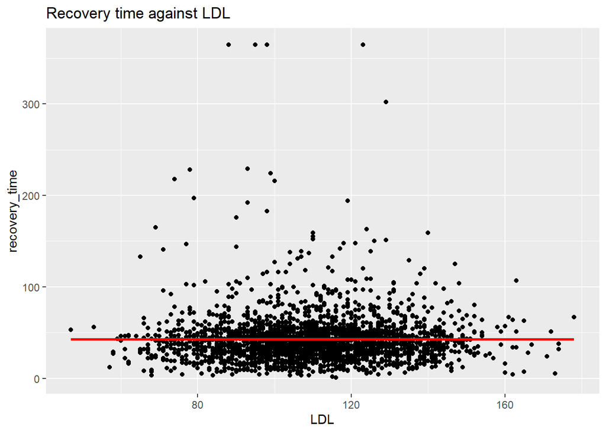

## Appendix 4

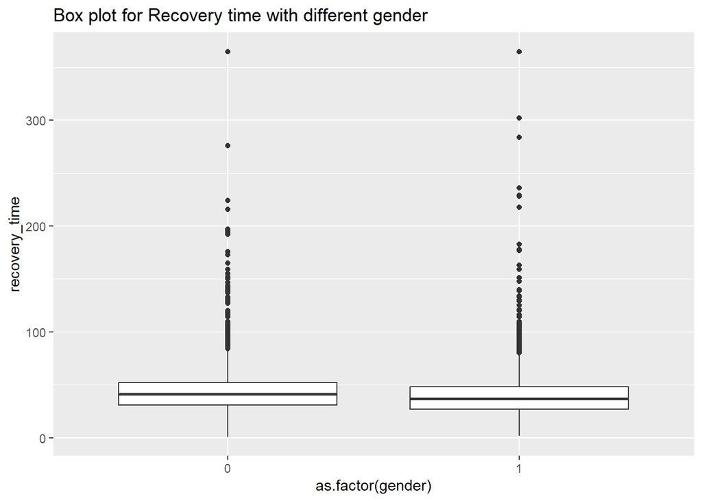

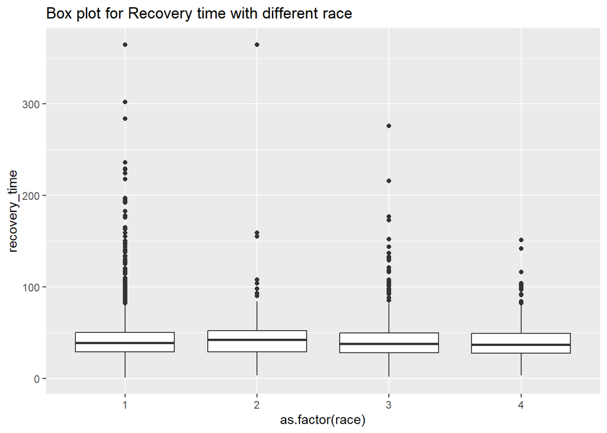

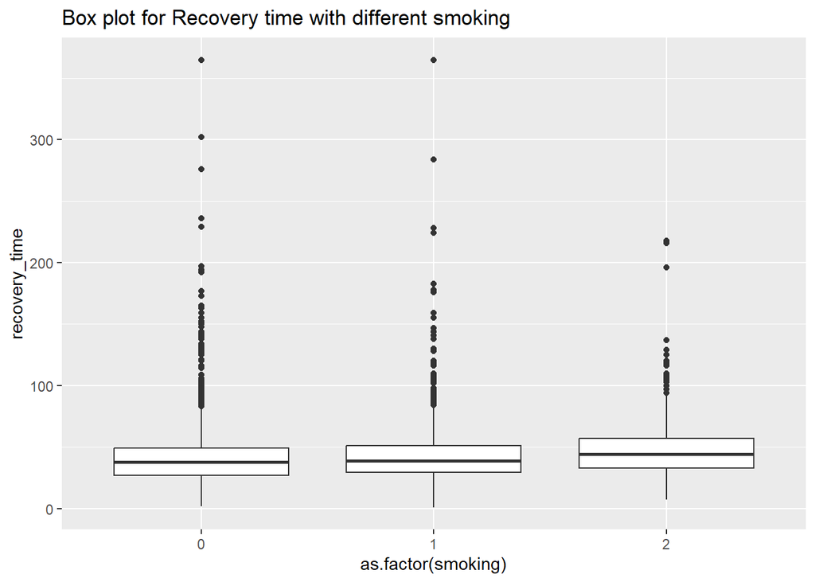

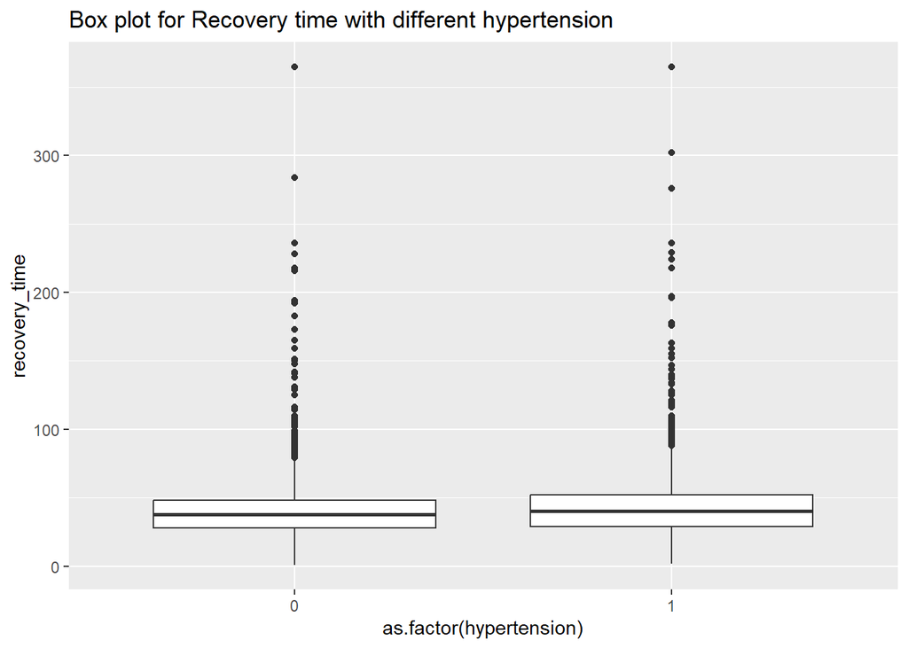

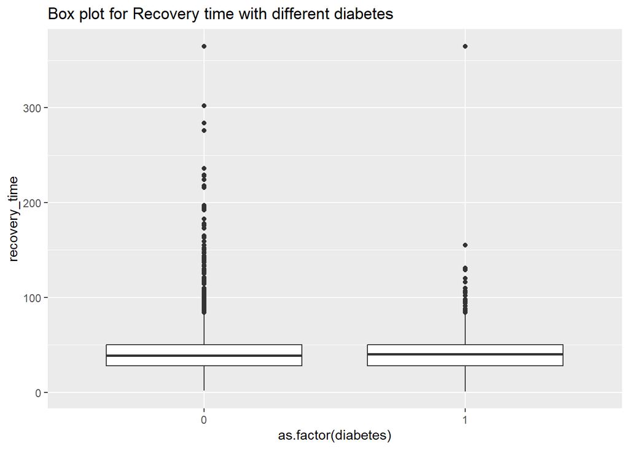

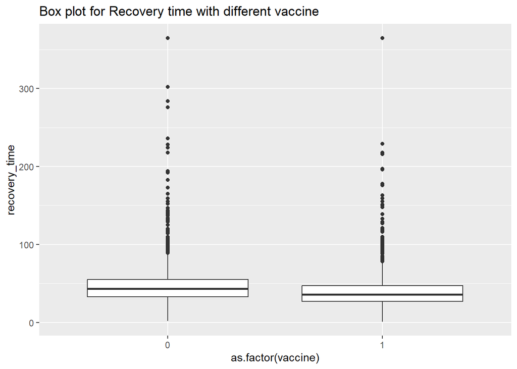

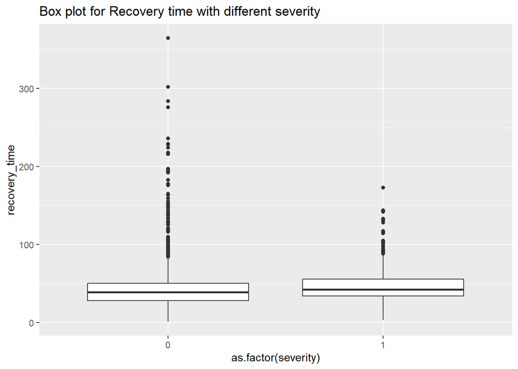

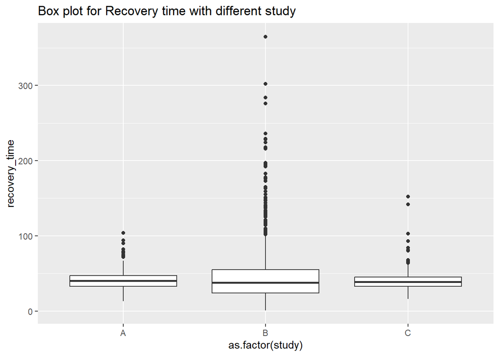